# Random Forest analysis of weight lifting exercise data

### Background

Human Activity Recognition has gained large impact in recent years as a way to use modern computational methods to analyze physical activity of individuals from sensory data attached to them.

A specific case is the Weight Lifting Exercise Dataset published by the [Groupware@LES](http://groupware.les.inf.puc-rio.br/har#ixzz38VUg0q7q). It contains sensory data from participants that were asked to perform one set of 10 repetitions of biceps curls in five different fashions. The categories are specified on their [webpage](http://groupware.les.inf.puc-rio.br/har#ixzz38VUg0q7q) and are: exactly according to the specification (Class A), throwing the elbows to the front (Class B), lifting the dumbbell only halfway (Class C), lowering the dumbbell only halfway (Class D) and throwing the hips to the front (Class E).

The aim is to quantify how accurate the participants are performing the barbell lifts by using data from accelerometers on the belt, forearm, arm, and dumbell of 6 participants.

### Preparation

The data used here is a version of the dataset from the [webpage](http://groupware.les.inf.puc-rio.br/har#ixzz38VUg0q7q) that is divided into a training set that contains the classe column with the categories that should be predicted and a test set without this column.

Before the start of the analysis the necessary libraries are loaded. I am using the Random Forest alogrithm and the caret package in R do perform the computations.

```r
library(caret)
```

### Data

The first step is to read in the training and test set. The data contains a lot of #DIV/0! entries. It is practical to convert them into NAs directly when reading from the files and treat them as missing data in the following.

```r
train.data <- read.csv("pml-training.csv", na.strings=c("NA", "#DIV/0!"),
                       row.names=1)
testing <- read.csv("pml-testing.csv", na.strings=c("NA", "#DIV/0!"),
                    row.names=1)
```

Next, the data is partitioned and a validation set is produced. This will help to get an estimate for the out of sample error. Once the data is divided, the validation and test set are not looked at and the choices made for the computational details are exclusively based on the training set. They are then applied in the same manner to the validation and test set.

```r
set.seed(25)
part <- createDataPartition(y=train.data$classe, p=0.8, list=FALSE)
train.sub <- train.data[part, ]
val.sub <- train.data[-part, ]
training <- subset(train.sub, select=-classe)
validation <- subset(val.sub, select=-classe)
```

Let's take a look a the dimensions of the training and validation set.

```r
dim(training)
```

```
## [1] 15699   158
```

```r
dim(validation)
```

```
## [1] 3923  158
```

There are 158 variables and 15699 cases in the data set. Taking a closer look at the variables in the data set and their characteristics helps to produce clean and useful data that can be fed into the Random Forest algorithm.

### Data processing

In general it helps to produce different statistics of the individual variables to get a better feeling of the characteristics of the data. I will not mention every step of the process but focus on the resulting conclusions. It is noticeable that the data contains some columns that are either describing the individual who is performing the exercise (*user_name*) or descriptions of several time attributes of the exercise (for example *raw_timestamp_part_1* and *new_window*). I chose not to consider these variables. Using too much information about the individual performing the exercise might help in reproducing the results from the training set very well but might produce a model that cannot generalize appropriately to other individuals. Furthermore it makes it easier to interpret the results when the variables can be distinctly assigned to a certain task performed by the participants.

```r
cols.rm <- c("user_name", "cvtd_timestamp", "raw_timestamp_part_1",
             "raw_timestamp_part_2", "num_window", "new_window")
sel.cols <- !(names(training) %in% cols.rm)
training <- subset(training, select=sel.cols)
validation <- subset(validation, select=sel.cols)
testing <- subset(testing, select=sel.cols)
```

In the next step all variables with zero variance are removed. The values of these variables are basically the same for all cases and therefore don't have any predictive power.

```r
nzv <- nearZeroVar(training, saveMetric=TRUE)
training.wz <- training[, !nzv$zeroVar]
validation.wz <- validation[, !nzv$zeroVar]
testing.wz <- testing[, !nzv$zeroVar]
```

Looking over the data set there appears to be a lot of missing values. To get a feeling for the distribution of the missing values across the the columns, the percentage of values that are missing for each variable can be calculated.

```r
na.ratio <- apply(training.wz, 2, function(x) sum(is.na(x))/nrow(training.wz))
summary(na.ratio)
```

```
##    Min. 1st Qu.  Median    Mean 3rd Qu.    Max.
##  0.0000  0.0000  0.9798  0.6239  0.9798  0.9841
```

This distribution of the percentage of missing values indicates that there are columns of variables that barely have any missing values at all and columns that mostly consist of missing values. Let's remove the later and look at the dimensions of the remaining data set.

```r
training.left <- training.wz[, na.ratio < 0.96]
validation.left <- validation.wz[, na.ratio < 0.96]
testing.left <- testing.wz[, na.ratio < 0.96]
sum(is.na(training.left))
```

```
## [1] 0
```

```r
dim(training.left)
```

```
## [1] 15699    52
```

This seems to have helped quite a bit. There are now no missing values left and the number of values has decreased to 52 which reduces the computational time needed for the calculations.

### Random Forest approach

We are now ready to apply a learning algorithm. I choose a Random Forest to analyze the dataset.

To estimate the computational time necessary for the analysis, first test calculations are performed for a varying number of trees, without cross validation and fine tuning of the parameters. The out of sample error is estimated with the out of bag error of the random forest.

```r
set.seed(1)
ntrees <- c(seq(1, 10, by=1), seq(10, 100, by=10), 200, 300, 400, 500)
times <- numeric()
oob.errors <- numeric()

tCtrl <- trainControl(method="oob")
for (i in seq_along(ntrees)){
  mod.rf <- train(x=training.left, y=train.sub$classe,
                  method="rf", ntree=ntrees[i], tuneLength=1,
                  trControl=tCtrl, preProcess=c("center", "scale"))

  times <- c(times, mod.rf$times$everything["elapsed"])
  oob.errors <- c(oob.errors, 1-mod.rf$results$Accuracy)
}
```

We can plot the results to check the accuracy of the calculation for each number of trees used.

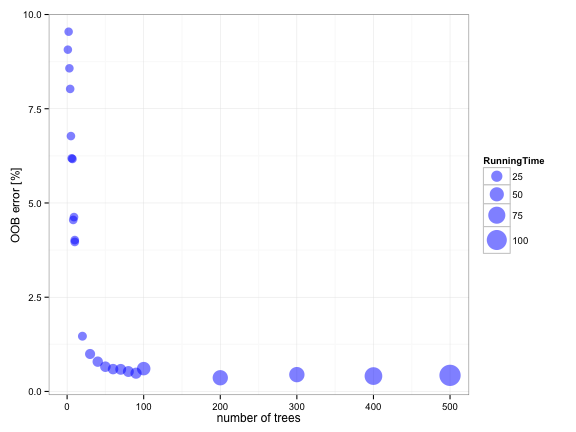

```r
plot.data.rf <- data.frame(n=ntrees, RunningTime=times, error=oob.errors*100)
g <- ggplot(data=plot.data.rf, aes(n, error, size=RunningTime))
g <- g + geom_point(color="blue", alpha=0.5)
g <- g + scale_size(range=c(4, 10))
g <- g + labs(x="number of trees", y="OOB error [%]")
g <- g + theme_bw()
g
```

It is clear from the plot that a too low number of trees would result in a significant loss of accuracy but that the results won't improve if more than a hundred trees are used.

I therefore calculate the Random Forest with 100 trees and this time use a 10 fold cross validation to estimate the out of sample error. Five different values for the parameter mtry are tested and the best one determined.

```r
set.seed(1)
tCtrl <- trainControl(method="cv", number=10)
mod.rf <- train(x=training.left, y=train.sub$classe,
                method="rf", ntree=100, tuneLength=5,
                trControl=tCtrl, preProcess=c("center", "scale"))
```

After the calculations are done we can take a look at the estimated errors for the different values of mtry.

```r
mod.rf
```

```
## Random Forest
##
## 15699 samples
##    52 predictors
##     5 classes: 'A', 'B', 'C', 'D', 'E'
##
## Pre-processing: centered, scaled
## Resampling: Cross-Validated (10 fold)
##
## Summary of sample sizes: 14131, 14129, 14128, 14129, 14128, 14130, ...
##
## Resampling results across tuning parameters:
##
##   mtry  Accuracy  Kappa  Accuracy SD  Kappa SD
##   2     0.993     0.991  0.0015       0.0019
##   14    0.994     0.993  0.00162      0.00205
##   27    0.993     0.991  0.00151      0.00191
##   39    0.99      0.988  0.00183      0.00232
##   52    0.985     0.982  0.00272      0.00344
##
## Accuracy was used to select the optimal model using  the largest value.
## The final value used for the model was mtry = 14.
```

The accuracy for all tried models is very high but the best result is achieved with a parameter of mtry=14. We can directly plot the train object to see the performance of the Random Forests for the different values of mtry that were tested in the model calculations.

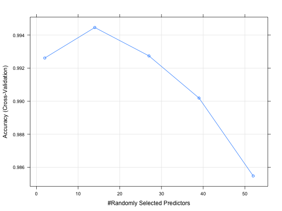

```r
plot(mod.rf)
```

### Results

The caret package saves the final model that was computed with the best fitting parameters in the train object. We can see how well it performed.

```r
mod.rf$finalModel
```

```
##
## Call:
##  randomForest(x = x, y = y, ntree = 100, mtry = param$mtry)
##                Type of random forest: classification
##                      Number of trees: 100
## No. of variables tried at each split: 14
##
##         OOB estimate of  error rate: 0.45%
## Confusion matrix:
##      A    B    C    D    E class.error
## A 4458    3    1    1    1 0.001344086
## B   14 3018    6    0    0 0.006583278
## C    0   10 2724    4    0 0.005113221
## D    0    0   21 2551    1 0.008550330
## E    0    0    3    6 2877 0.003118503
```

The confusion matrix shows that there are only a few cases that are missclassified. The error rate is less than 1%!

Another thing that might be of interest is the importance of each variable for the calculations. Random Forests use a measure called MeanDecreaseGini that measures the [Gini decreases](http://www.stat.berkeley.edu/%7Ebreiman/RandomForests/cc_home.htm#giniimp) for each variable as an indicator for the importance of a variable.

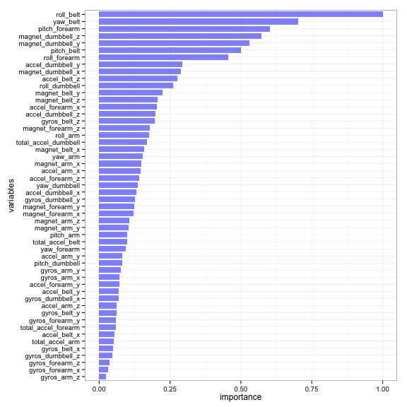

```r
importance <- importance(mod.rf$finalModel)[, 1]
variables <- names(importance)
ordering <- order(importance)
variables <- variables[ordering]
variables <- factor(variables, level=variables)
importance <- importance[ordering]/max(importance)

plot.data <- data.frame(variables=variables, importance=importance)
g <- ggplot(data=plot.data, aes(x=variables, y=importance))
g <- g + geom_bar(aes(width=0.8), stat="identity", fill="blue", alpha=0.5)
g <- g + coord_flip()
g <- g + theme_bw()
g
```

It appears that the most important sensor is located at the belt while the data from the arm sensor has less influence on the predictions.

Now it's time to use the validation set to get the prediction for an untouched set of data and get another and possibly better estimate for the out of sample error.

```r
pred.val <- predict(mod.rf, validation.left)
confusionMatrix(pred.val, val.sub$classe)
```

```
## Confusion Matrix and Statistics
##
##           Reference
## Prediction    A    B    C    D    E
##          A 1116    2    0    0    0
##          B    0  755    1    0    0
##          C    0    2  683    7    0
##          D    0    0    0  636    1
##          E    0    0    0    0  720
##
## Overall Statistics
##
##                Accuracy : 0.9967
##                  95% CI : (0.9943, 0.9982)
##     No Information Rate : 0.2845
##     P-Value [Acc > NIR] : < 2.2e-16
##
##                   Kappa : 0.9958
##  Mcnemar's Test P-Value : NA
##
## Statistics by Class:
##
##                      Class: A Class: B Class: C Class: D Class: E
## Sensitivity            1.0000   0.9947   0.9985   0.9891   0.9986
## Specificity            0.9993   0.9997   0.9972   0.9997   1.0000
## Pos Pred Value         0.9982   0.9987   0.9870   0.9984   1.0000
## Neg Pred Value         1.0000   0.9987   0.9997   0.9979   0.9997
## Prevalence             0.2845   0.1935   0.1744   0.1639   0.1838
## Detection Rate         0.2845   0.1925   0.1741   0.1621   0.1835
## Detection Prevalence   0.2850   0.1927   0.1764   0.1624   0.1835
## Balanced Accuracy      0.9996   0.9972   0.9979   0.9944   0.9993
```

The confusion matrix again shows very few missclassified values and the accuracy is almost a hundred percent. The Random Forest did very well on this kind of data and is able to predict the execution of the weight lifting exercise with a very low error rate.